| 1 | import numpy as np |
| --- | --- |
| 2 | import matplotlib.pyplot as plt |
| 3 | import sympy as sp |
| 4 | from sympy.plotting import plot |
| 5 | import operator |
| 6 | from IPython.display import Image |
| 7 | from IPython.core.display import HTML |
| 8 |  |
| 9 | from Numerical_Methods import * |

# Introduction

### What is Economic Growth?

Economic growth is used by Economists in many ways. They use it to adjust future expectations and measure the efficiency of the country's governance and market total output. Economic growth can be measured by the potential and actual output, and output can be measured by GDP, or Gross Domestic Product. GDP is comprised of consumption spending, investment, government expenditures, and net exports. There are many things that can hinder or help the development of economic growth, and therefore the country's growth. These are things such as:

- Openness of the market
- Labor force and labor force participation rate
- Capital
  - human
  - physical
- Relative income
- Depreciation
- Investment
- Technology
- Population and population growth
- Efficiency
- Productivity
- Governance
  - rule of law
  - ease of business
  - patent creation

### What is the Ramsey Model?

The Ramsey–Cass–Koopmans model, or Ramsey growth model, is a neoclassical model of economic growth based primarily on the work of Frank P. Ramsey. The Ramsey Model includes a system of equations for Capital (represented by K) and Consumption (represented by C). Together, we try to model the optimal growth of the economy so that we can optimize consumption and capital in order to reach the steady state solutions. Within these models, we can add functions or variables that acount for behavioral economics such as commitment technologies, present bias, and/or discounting. By the end of this study, we added these things to the Ramsey Model:

- population growth, $n$
  - This effects economic growth because it effects output per capita.
- the depreciation of capital, $\delta$
  - where "depreciation" means diminishing value over time
  - For physical capital, this is like buildings or roads needing repairs and their value diminishing over time.
  - For human capital, it can be things like aging and then going into retirement or certain skills getting outmoded with time.
- the cost of technological upkeep, $x$
  - this cost can vary depending whether you are a developing country or a developed country. To be specific, if you are a developed country, you are paving the road for more development which takes a lot of resources like time, effort and money. This is as opposed to trying to catch up to technological advancements that already exist, which is "catching up growth"; this occurs more quickly and is cheaper.
  - To be specific, the so-called cost of technological upkeep is actually the cost of investments into R and D creation, and is actually risky; there is a tradeoff between riskiness and reliability when it comes to choosing to invest in a developed country or a developing country. Unfortunately, it is a lot more reliable to invest in a developed country, despite the growth of developing countries being dependent on the amount of investment put into these countries.
- Behavioral economic factors
  - present bias, $\phi(t)$, which is valuing our present utility over future utility. It can also be called time preference.
  - discounting, $\frac{\rho}{\beta}$, which means discounting the future cost of actions, such as being more willing to go to the gym tomorrow versus today.
  - how effective present bias is, $\gamma$, as in how much more do we value our present utility</font>
  - time, $t$, because present bias is time-dependent

### Modifications of the Ramsey model: a History

##### The Ramsey Model:

The Ramsey Model has been created and modified by many people over time. For instance, it is actually called the Ramsey-Cass-Koopmans model because it was originally developed by these three people. From there, it has been edited by both Laibson and Barro.

##### What the Ramsey Model was initially:

$\begin{array}{l} \dot{k}=f(k)-c \\ \dot{c}=c\left(f^{\prime}(k)-\rho\right) \end{array}$

for a given output function, $f(k)$ and long-run rate of time preference, $\rho$. To be clear, the output function is how much output we get given our capital.

using the Cobb-Douglas output function, $f(k) = k^\alpha$, we get:

$\begin{array}{l} \dot{c}=c\left(\alpha k^{\alpha-1}-\rho\right) \\ \dot{k}=k^{\alpha}-c \end{array}$

##### How do we go about solving this?

This is an Initial Value Problem, so we solve it "forwards" or "backwards" given some initial conditions.

For what we call "forwards" solving, these initial conditions are literally the initial values, and specify where we should begin modeling from. In our case, Economists want to find the Policy Function which is the equation that will take us to the steady state solution. This means we do not necessarily know what our initial values are. Therefore, we instead try to work "backwards" from the steady state solution.

This means, for what we call "backwards solving", we perturb, or move, slightly off of the steady state solution by some infinitesimal value and try to solve the equation backwards to find the initial values.

For our equations, we are given the initial k-value, so when solving forwards, we use it and some found c-value, otherwise, when bacwards solving, we try to work backwards from the steady state so that we arrive perfectly at the given k-value, which proves difficult. We will outline throughout this notebook how we went about doing this.

##### What is an Initial Value Problem (IVP)?

An IVP is an ordinary differential equation that also has an initial condition. This initial condition specifies a specific solution, a function, for a given time frame within the domain. Modeling systems frequently means in the sciences, such as Economics for us, solving an initial value problem. For that context, the resulting equation models how the system evolves with time given the initial conditions.

##### Solving the old system of equations:

making some assumptions with $\alpha=0.5$ and $\rho=0.1$,

| 1 | sys = [lambda t, k,c : k**0.5 - c, lambda t, k,c : 0.5*c*(k)**(-0.5) - 0.1*c] |
| --- | --- |

##### Forward-solving the original Ramsey Model:

As a review, "forward solving" for us means solving the initial value problem given some initial conditions. In this case, these initial conditions are $k_0$, pronounced "k-naught", and $c_0$, pronounced similarly.

| 1 | plot_flow(sys, [0, 30], [0, 10], 20) |
| --- | --- |
| 2 |  |
| 3 | #solving forward: |
| 4 | tf = 74 |
| 5 |  |
| 6 | plot_IVP(sys, [0.01285009, 0.02446086], [0, tf]); |
| 7 |  |
| 8 | #add isoclines: |
| 9 | k = np.linspace(0,30,40) |
| 10 | c = np.sqrt(k) # dk = sqrt(k) - c with dk = 0 |
| 11 | # dc = 0 implies 0.5/sqrt(k) - 0.1 = 0 so k = 25 |
| 12 | plt.plot(k,c,'b',[25,25],[0,10],'r',25,5,'go'); |

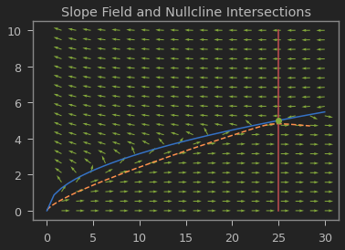

##### Backward-solving the original Ramsey Model:

As a review, "backward solving" is still an IVP but instead of having initial conditions at the traditional starting points, we start at a given point, for us a slight perturbation off of the steady state solution, and move backwards in time from some final time down to zero.

| 1 | plot_flow(sys, [0, 30], [0, 10], 20) |
| --- | --- |
| 2 |  |
| 3 | k0 = 25 |
| 4 | perturbation = 0.01 |
| 5 | c0 = 5-perturbation |
| 6 | tf =300 |
| 7 |  |
| 8 | plot_IVP(sys, [k0, c0], [tf, 0]); |
| 9 |  |
| 10 | #add isoclines: |
| 11 | k = np.linspace(0,30,40) |
| 12 | c = np.sqrt(k) # dk = sqrt(k) - c with dk = 0 |
| 13 | # dc = 0 implies 0.5/sqrt(k) - 0.1 = 0 so k = 25 |
| 14 | plt.plot(k,c,'b',[25,25],[0,10],'r',25,5,'go'); |

[figure not shown]

As you can see, the graphs produce similar results that were also what we expected so we know these methods currently work.

### Laibson and Baro's Modifications to the Ramsey Model

##### What Laibson had done already:

First, Laibson added depreciation of capital, $\delta$, and discounting in the form of $\frac{\rho}{\beta}$, $\rho$ being the long-term rate of time preference, i.e. how does a rational person that is not affected by present bias view this capital, and $\beta$ being the short-term rate of time preference, or how does the person being affected by present bias view it.

$\begin{array}{l} \dot{k}=k^{\alpha}-c-\delta k \\ \dot{c}=c\left(\alpha k^{\alpha-1}-\delta-\frac{\rho}{\beta}\right) \end{array}$

He then continued to add population growth, $n$, technological upkeep, $x$, and the function for present bias, $\phi(t)=be^{-\gamma t}$. He also adds $\lambda$ which represents the "effective" rate of time preference, effective implying we are linearlizing the time preference to find its approximation i.e. how much present bias is effecting our decision. It will be a lot in the short term and less in the long term. $\lambda$ is bounded by ${\rho ≤ \lambda ≤ \rho+𝜙'(0)}$.

###### Laibson ends up with these systems of equations:

Full Commitment: \begin{align} \dot{k} &= k^\alpha - \left(\delta + n + x\right)k - c\\ \dot{c} &= c\left(\alpha k^{\alpha - 1} - \left(\delta + x\right) - \left(\rho + be^{-\gamma t}\right) \right) \end{align}

No Commitment: \begin{align} \dot{k} &= k^\alpha - \left(\delta + n + x\right)k - c\\ \dot{c} &= c\left(\alpha k^{\alpha - 1} - \left(\delta + x + \lambda\right) \right) \end{align}

##### What Baro added to Laibson's work:

Laibson believed it was a discontinuous jump from present bias to no present bias, but Baro made it a continuous line between the two. This makes the model easier to work with.

##### Finding some initial values to work with to solve our system of equations:

Down below, $\left(k_{\infty}^{*}-k_{0}^{*}\right) / k_{0}^{*}$ is something called the "relative measure" between our long-term capital and our short-term capital. In other words, this is the difference between our long-term steady state and our short-term steady state of capital. The same applies to the relative measure of consumption, $\left(c_{\infty}^{*}-c_{0}^{*}\right) / c_{0}^{*}$ .

| 1 | α = 0.75 # modifies the output function, as in how much output we get out given our capital |
| --- | --- |
| 2 | δ = 0.05 # represents the depreciation of capital |
| 3 | x = 0.02 # represents the cost of technological upkeep |
| 4 | b = 0.5 # b represents the upper bound of present bias |
| 5 | ρ = 0.02 # represents the amount of base utility we get without present bias affecting it |
| 6 | γ = 0.5 # represents how effective present bias is (in the short-term) (rate of decay of phi'(t)) |
| 7 | τ = 0.0 # represents the current day, where τ=0 means time starts today |
| 8 | n = 0.01 # represents the cost of effective worker upkeep |
| 9 | λ = 0.036528 # represents present bias |
| 10 |  |
| 11 | full_commitment = [lambda t, k,c : k**α-c-(δ+x+n)*k, lambda t, k,c : c*(α*k**(α-1)-δ-x-ρ-b*np.exp(-γ*(t-τ)))] |
| 12 | no_commitment = [lambda t, k,c : k**α-c-(δ+x+n)*k, lambda t, k,c : c*(α*k**(α-1)-δ-x-λ)] |
| 13 |  |
| 14 | # for use of the Gauss-Laguerre Quadrature when solving for lambda: |
| 15 | # f(x) = e^(-phi'(v)) |
| 16 | def f(x): |
| 17 | return np.exp( -((b/γ)*(1-np.exp(-γ*x)))) |
| 18 |  |
| 19 | N=100 |
| 20 | data = [[0.75,0.75,0.75, 0.33, 0.33, 0.33], |
| 21 | [ 0.5, 0.2, 0.1, 0.5, 0.2, 0.1], |
| 22 | [], |
| 23 | [], |
| 24 | []] |
| 25 |  |
| 26 | λ_data = [] |
| 27 | b_data = data[1] |
| 28 |  |
| 29 | kinf_steady = [] |
| 30 | cinf_steady = [] |
| 31 | k0_steady = [] |
| 32 | c0_steady = [] |
| 33 |  |
| 34 | for b in b_data: |
| 35 | convertWith = 1/(ρ-n) |
| 36 | Ω = gauss_laguerre_quadrature(f,convertWith,N) |
| 37 | λ = n + 1/Ω |
| 38 | λ_data.append(λ) |
| 39 | data[2] = λ_data |
| 40 |  |
| 41 | alpha = data[0] |
| 42 | k_relative_measure = [] |
| 43 | c_relative_measure = [] |
| 44 |  |
| 45 | for i in range(6): |
| 46 | kinf = ((δ+x+ρ)/alpha[i])**(1/(alpha[i]-1)) |
| 47 | cinf = kinf**alpha[i]-(δ+x+n)*kinf |
| 48 | kinf_steady.append(kinf) |
| 49 | cinf_steady.append(cinf) |
| 50 |  |
| 51 | k0=((δ+x+λ_data[i])/alpha[i])**(1/(alpha[i]-1)) |
| 52 | c0 = k0**alpha[i]-(δ+x+n)*k0 |
| 53 | k0_steady.append(k0) |
| 54 | c0_steady.append(c0) |
| 55 |  |
| 56 | k_rm = (kinf-k0)/k0 |
| 57 | c_rm = (cinf-c0)/c0 |
| 58 | k_relative_measure.append(k_rm) |
| 59 | c_relative_measure.append(c_rm) |
| 60 |  |
| 61 | data[3] = k_relative_measure |
| 62 | data[4] = c_relative_measure |
| 63 |  |
| 64 | table = pd.DataFrame(data[:5], columns=["(1)","(2)","(3)","(4)","(5)","(6)"], |
| 65 | index = ["α","b = φ'(0)", "λ", |
| 66 | '<img src="https://cdn.discordapp.com/attachments/557363729759469578/726067490941304932/unknown.png" alt="img">', |
| 67 | '<img src="https://cdn.discordapp.com/attachments/557363729759469578/726084138192339024/unknown.png" alt="img">']) |
| 68 | display(HTML(table.to_html(escape=False))) |

|  | (1) | (2) | (3) | (4) | (5) | (6) |
| --- | --- | --- | --- | --- | --- | --- |
| α | 0.750000 | 0.750000 | 0.750000 | 0.330000 | 0.330000 | 0.330000 |
| b = φ'(0) | 0.500000 | 0.200000 | 0.100000 | 0.500000 | 0.200000 | 0.100000 |
| λ | 0.036528 | 0.024792 | 0.022164 | 0.036528 | 0.024792 | 0.022164 |
|  | 0.962868 | 0.230583 | 0.099718 | 0.286139 | 0.080497 | 0.036104 |
|  | 0.265594 | 0.061101 | 0.025718 | 0.020842 | 0.004795 | 0.002006 |

# Solving their Systems of Equations:

Due to the nature of full commitment not being solvable by the same means no commitment was, the full commitment case must be solved backwards from the equilibrium values found previously through solving the system of equations, the “solution” that will be found by this solver will come at roughly k(0) which we got from the Baro paper to be $.25k^{*}_0$ (this is the equilibrium solution for the non-commitment case of a given system, ex: $k_0^*=2459.49884228438$ by which k(0) is roughly 614.22 for column 1)

By using a “shooting” method alongside a numerical value estimation technique such as the bisection or secant method (by which were chosen due to their non-reliance on taking a derivative as the given equations would not be easy to work with in terms of their derivatives). This means we can therefore “get off” or perturb on both sides of the equilibrium solution (above and below) for c*(inf) (ex: 192.90 for column 1), we can safely narrow down where exactly the initial point must be in order for the given equations to result in that equilibrium solution that was the starting point of the solver. Thus as an example (which may or may not be shown below) for the first column this resulting value is roughly 77.2.

The benefit of this implementation in particular is the only variables that are needed to be given to solve for this value are a final time value (ex: 120 for columns 1-3 seemed to be a good fit) and a maximum iteration count by which is essentially just a limit for how many iterations the solver is required/allowed to do before giving up (by which does not seem to be reached unless set fairly/very low. (Additionally it has been discovered that as the overall range of vallues occuring through the system of equations lowers the boundary by which restricts the intepolation/shooting method needs to be lowered in an equivalent fashion, see next paragraph)

NOTE: For columns 4-6 tf=50-55 these should provide accurate c(0)'s for all the columns from the original table we were working with, additionally the bound variable (which had been set to [0,100] for the previous 3 cases) is now changed to [0,0.01] this is in order to assure the bounding of the graph is more accurate given the much smaller scale of the values overall when alpha is changed to that lower value.

Using the intuition that can be gathered from the 6 test cases we had initially been given, it would appear that alpha is the main variable of concern regarding when the desired modifiable variables must be modified, for instance in the cases provided which were split evenly between alpha = .75 and alpha = .33, it was found that tf only needed to be different 3 times (this may just come from calculation variance and not necessarily the reliance on tf strictly) tf was 120 for all cases by which alpha = .75 and was either 55 or 50 depending on the column for alpha = .33, there is a rough mathematical formula that can be used to calculate a ballpark value by which other alpha values could be tested, start by taking the alpah values you are working with (say .33) and divide that by a preexisting alpha value you know tf for (because there has already been test cases here try .75 but additionally later .33 could be used this is for the sake of example) By which this percentage relative to the previous alpha value is then multiplied by the tf for the same alpha value (so for alpha = .75 tf=120)

An example of the previous calculations to get a ballpark value for tf for alpha = .33 would look like the following:

.33/.75 = .44

.44(120) = 52.8

52.8 is roughly between 50 and 55 which was what had been used to find solid initial values for c(0) in all cases tested.

To combat this, we found three different methods to find an adequate value for the perturbation, our so-called "machine gun method", the bisection method, and the secant method (in order from worst to greatest in terms of efficiency).

| 1 | ### The methods we tried for finding the perturbation: |
| --- | --- |
| 2 |  |
| 3 | def LF_secant_method(MAX_IT, tolerance): |
| 4 |  |
| 5 | tic = timeit.default_timer() |
| 6 | i=0 |
| 7 | error = tolerance+1 |
| 8 | eps = 1e-4 |
| 9 |  |
| 10 | c_upper = cinf_steady[table_i]+eps #the "plus eps" is to give something other than the steady state |
| 11 | c_lower = cinf_steady[table_i]-eps |
| 12 | k_init = kinf_steady[table_i] |
| 13 |  |
| 14 | #find initial k_lower |
| 15 | init_pt = [k_init, c_lower] |
| 16 | t, v = plot_time_series(full_commitment, init_pt,[tf,0]) #backward solve |
| 17 | k_lower = v[-1][0] |
| 18 |  |
| 19 | # REMOVED FIND INITIAL K_UPPER -- FIND IT WITHIN THE LOOP |
| 20 |  |
| 21 | while (i<MAX_IT and error > tolerance): |
| 22 |  |
| 23 | # Evalute the function |
| 24 | fl = k_lower-init_k0 |
| 25 |  |
| 26 | #find k_upper |
| 27 | init_pt = [k_init, c_upper] |
| 28 | t, v = plot_time_series(full_commitment, init_pt,[tf,0]) #backward solve |
| 29 | k_upper = v[-1][0] |
| 30 |  |
| 31 | # STORE K_UPPER TO BE SWAPPED TO K_LOWER AFTER ITS USED IN FU COMPUTATION |

[output cut: 74 more lines]

| 1 | table_i=0 #Using the first set of assumptions for our variables from row 1 |
| --- | --- |
| 2 |  |
| 3 | α=alpha[table_i] |
| 4 | λ = λ_data[table_i] |
| 5 | b = b_data[table_i] |

| 1 | ### Backward solving with the Bisection method for finding the perturbation: |
| --- | --- |
| 2 |  |
| 3 | full_commitment = [lambda t, k,c : k**α-c-(δ+x+n)*k, lambda t, k,c : c*(α*k**(α-1)-δ-x-ρ-b*np.exp(-γ*(t-τ)))] |
| 4 |  |
| 5 | # solve the systems of equations for c0: |
| 6 | tf = 120 |
| 7 | init_k0 = .25*k0_steady[table_i] |
| 8 |  |
| 9 | #full commitment steady state |
| 10 | plt.plot([0,tf], [cinf_steady[table_i], cinf_steady[table_i]], 'b--', label="full commitment steady state") |
| 11 |  |
| 12 | #solve for the perturbation off of the steady state that gives us an adequate c0 |
| 13 | tolerance = 1e-4 |
| 14 | MAX_IT=50 |
| 15 | p, bound_of_p = LF_bisection_method([0,100], MAX_IT, tolerance) |
| 16 |  |
| 17 | #plot with the found perturbation |
| 18 | init_pt = [kinf_steady[table_i], cinf_steady[table_i]-p] |
| 19 | t, v = plot_time_series(full_commitment, init_pt,[tf,0]) |
| 20 | plt.plot(t,v[:,1], 'r', label="full commitment") |
| 21 | print(f'[k(0), c(0)] for full commitment is currently {v[-1]}') |

```
iteration 1
iteration 2
iteration 3
iteration 4
iteration 5
iteration 6
iteration 7
iteration 8
iteration 9
iteration 10
iteration 11
iteration 12
iteration 13
iteration 14
iteration 15
iteration 16
iteration 17
iteration 18
iteration 19
Run complete in 11.06 seconds.
[k(0), c(0)] for full commitment is currently [614.23265464  77.20736773]
```

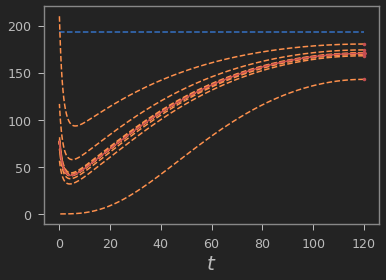

| 1 | ### Backward solving with the Secant method for finding the perturbation: |
| --- | --- |
| 2 |  |
| 3 | #full commitment steady state |
| 4 | plt.plot([0,tf], [cinf_steady[table_i], cinf_steady[table_i]], 'b--', label="full commitment steady state") |
| 5 |  |
| 6 | #solve for the perturbation off of the steady state that gives us an adequate c0 |
| 7 | perturbation = LF_secant_method(MAX_IT, tolerance) |
| 8 |  |
| 9 | #plot with the found perturbation: |
| 10 | init_pt = [kinf_steady[table_i], cinf_steady[table_i]-perturbation] |
| 11 | t, v = plot_time_series(full_commitment, init_pt,[tf,0]) |
| 12 | plt.plot(t,v[:,1], 'r', label="full commitment") |
| 13 | print(f'[k(0), c(0)] for full commitment is currently {v[-1]}') |

```
iteration 1
iteration 2
iteration 3
iteration 4
iteration 5
iteration 6
iteration 7
iteration 8
Run complete in 5.43 seconds.
[k(0), c(0)] for full commitment is currently [614.23265464  77.20736773]
```

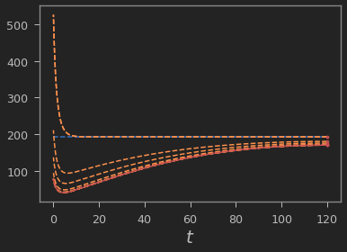

# Using the Jacobian for further analysis of the system

##### The Jacobian of the system:

$$J(k,c)= \begin{bmatrix} \alpha k^{\alpha-1}-\left(\delta+n+x\right) & -1\\ \alpha(\alpha-1)ck^{\alpha-2} & \alpha k^{\alpha - 1} - \left(\delta + x\right) - \left(\rho + be^{-\gamma t}\right)\\ \end{bmatrix}$$

$$J(k,c)= \begin{bmatrix} \alpha k^{\alpha-1}-\left(\delta+n+x\right) & -1\\ \alpha(\alpha-1)ck^{\alpha-2} & 0\\ \end{bmatrix}$$

Through this we can find the eigenvalues and eigenvectors of the Jacobian matrix to check the stability of the system as it is centered at the steady state.

| 1 | def nullcline_intersection(sys, r): |
| --- | --- |
| 2 | x, y = sp.symbols('x, y') |
| 3 | eq1 = sys(x, y, r)[0] |
| 4 | eq2 = sys(x, y, r)[1] |
| 5 | sols = sp.solve([eq1, eq2], [x, y]) |
| 6 | return np.array(sols,dtype=float) |

| 1 | def jacsys(k,c,r): |
| --- | --- |
| 2 | alpha, delta, xt, n, rho, b, gamma = r[0], r[1], r[2], r[3], r[4], r[5], r[6] |
| 3 | J = np.array([[alpha*k**(alpha-1)-(delta+xt+n), -1], |
| 4 | [c*alpha*(alpha-1)*k**(alpha-2), 0]]) |
| 5 | return J |

| 1 | # Use the RK4 solver to complete Linearizing the Jacobian |
| --- | --- |
| 2 | def rk4(t,y,h,func,J): |
| 3 | k1 = h*func(t,y,J) |
| 4 | k2 = h*func(t+0.5*h,y+0.5*k1,J) |
| 5 | k3 = h*func(t+0.5*h,y+0.5*k2,J) |
| 6 | k4 = h*func(t+h,y+k3,J) |
| 7 | return (k1 + 2*k2 + 2*k3 + k4)/6 |
| 8 |  |
| 9 | # Homebrew Solver: Euler's Method |
| 10 | def rk4_solve(t0,tf,h,y0,func,J): |
| 11 | tv, yv, = [], [] |
| 12 | t, y = t0, y0 |
| 13 | while t < tf: |
| 14 | y += rk4(t,y,h,func,J) |
| 15 | t += h |
| 16 | yv.append(y.copy()) |
| 17 | tv.append(t) |
| 18 | return np.array(tv), np.array(yv) |
| 19 |  |
| 20 | # Take the values close to the steady-point to see the stability around each point placed in J |
| 21 | def F(t,U,J): |
| 22 | # System of Equations |
| 23 | return np.array([ J[0,0]*U[0] + J[0,1]*U[1], |
| 24 | J[1,0]*U[0] + J[1,1]*U[1]]) |

###### Values Used

Values of this problem are shown around the original first column values in Barrows table.

The kzed, czed and kinf, cinf are calculated by linearizing \dot{k}, \dot{c}.

| 1 | alpha, delta, xt, n, rho, b, gamma = 0.75, 0.05, 0.02, 0.01, 0.02, 0.5, 0.5 |
| --- | --- |
| 2 | r = (alpha, delta, xt, n, rho, b, gamma) |
| 3 | lam = .03653 |
| 4 |  |
| 5 | # Equations of k*_0 and c*_0 for No Commitment |
| 6 | kzed = (alpha/(delta + lam + xt))**(1/(1-alpha)) |
| 7 | czed = kzed**alpha - (delta + n + xt)*kzed |
| 8 |  |
| 9 | # Equations of k*_inf and c*_inf for Full Commitment |
| 10 | kinf = (alpha/(delta + rho + xt))**(1/(1-alpha)) |
| 11 | cinf = kinf**alpha - (delta + n + xt)*kinf |

###### Based on the Commitment Type we are able to analyze the different stabilities created by the different states.

To analyze a different commitment, simply change the CommitmentType, True represents the Full Commitment and False represents No Commitment.

In each case the derivative of that equations is used to set up their specific Jacobian using the correct steady-state and derivatives.

###### The Eigenvalues

Based on the eigenvalues of the Jacobian we are able to see how the area around the steady-state will react, whether it is stable, semi-stable, or unstable. The eigenvalues having a switched sign (one positive, one negative), it shows this problem is semi-stable, with a saddle point.

This can be analyzed by the converging or diverging of the values to and away from the the centeralized steady point.

| 1 | # To Test Full or No Commitment change below |
| --- | --- |
| 2 | # True = Full Commitment |
| 3 | # False = No Commitment |
| 4 | CommitmentType = True |
| 5 |  |
| 6 | if CommitmentType: |
| 7 | # Jacobian of the Full Comittment Case |
| 8 | def dFull(k,c,r): |
| 9 | alpha, delta, xt, n, rho, b, gamma = r[0], r[1], r[2], r[3], r[4], r[5], r[6] |
| 10 | G1 = k**alpha - (delta+xt+n)*k - c |
| 11 | G2 = c*(alpha*k**(alpha-1) - (delta+xt) - rho) # b*exp(-gamma*t) -> 0 as t -> infty |
| 12 | return [G1, G2] |
| 13 |  |
| 14 | eq = nullcline_intersection(dFull,r) |
| 15 | Jacobian = jacsys(kinf,cinf,r) |
| 16 | Jentries = np.array([[Jacobian[0,0],Jacobian[0,1]],[Jacobian[1,0],Jacobian[1,1]]]) |
| 17 | print("The Full Commitment Case:") |
| 18 |  |
| 19 | else: |
| 20 | # Jacobian of the No Comittment Case |
| 21 | def dNo(k,c,r): |
| 22 | alpha, delta, xt, n, rho, b, gamma = r[0], r[1], r[2], r[3], r[4], r[5], r[6] |
| 23 | G1 = k**alpha - (delta+xt+n)*k - c |
| 24 | G2 = c*(alpha*k**(alpha-1) - (delta+xt) - lam) |
| 25 | return [G1, G2] |
| 26 |  |
| 27 | eq = nullcline_intersection(dNo,r) |
| 28 | Jacobian = jacsys(kzed,czed,r) |
| 29 | Jentries = np.array([[Jacobian[0,0],Jacobian[0,1]],[Jacobian[1,0],Jacobian[1,1]]]) |
| 30 | print("The No Commitment Case:") |
| 31 |  |
| 32 | print("The Jacobian Matrix of the No Committment case:") |
| 33 | print(Jacobian) |
| 34 | print(" ") |
| 35 | ew, ev = np.linalg.eig(Jacobian) |
| 36 | print('The Eigenvalues: {}'.format(ew)) |
| 37 | print('The Eigenvectors: {}'.format(ev)) |

```
The Full Commitment Case:
The Jacobian Matrix of the No Committment case:
[[ 1.e-02 -1.e+00]
 [-9.e-04  0.e+00]]

The Eigenvalues: [ 0.03541381 -0.02541381]
The Eigenvectors: [[ 0.99967723  0.99937352]
 [-0.02540561  0.03539163]]
```

###### Plotting the values about the steady-state that is centered around [0,0].

Through the use of the RK4 solver, by taking values from the the four quadrants about the steady-state of each No and Full Commitment case, we are able to see the stability of each of these areas.

Each of these quadrands are shown below, with the line highlighted in different colors. The green dots represent the original value of where the line starts and how it vears to the steady point or moves away.

Due to the graph structure, each of these lines look as though they are straight, although when zoomed into each line it is easier to see the curvature of each values stability.

| 1 | UpLfQ = [-0.005, .005] # Value in upper left quadrant (Blue) |
| --- | --- |
| 2 | UpRtQ = [0.01, .005] # Value in upper right quadrant (Red) |
| 3 | LwLfQ = [-0.01, -0.005] # Value in lower left quadrantn(Purple) |
| 4 | LwRtQ = [0.005, -0.005] # Value in lower right quadrant (Yellow) |
| 5 |  |
| 6 |  |
| 7 | t,v = rk4_solve(0,4,1e-2, UpLfQ,F,Jentries) |
| 8 | t2,v2 = rk4_solve(0,2,1e-2, UpRtQ,F,Jentries) |
| 9 | t3,v3 = rk4_solve(0,2,1e-2, LwLfQ,F,Jentries) |
| 10 | t4,v4 = rk4_solve(0,2,1e-2, LwRtQ,F,Jentries) |
| 11 |  |
| 12 | if CommitmentType == True: |
| 13 | print("Full Commitment Case:") |
| 14 | else: |
| 15 | print("No Commitment Case:") |
| 16 |  |
| 17 |  |
| 18 | plt.plot(v[:,0],v[:,1], 'b',v2[:,0], v2[:,1],'r',v3[:,0], v3[:,1],'m',v4[:,0], v4[:,1],'y', |
| 19 | [-.009,.009],[0,0],'k',[0,0],[-.009, .009],'k', |
| 20 | UpRtQ[0], UpRtQ[1],'go',UpLfQ[0], UpLfQ[1],'go',LwRtQ[0],LwRtQ[1],'go',LwLfQ[0],LwLfQ[1],'go'); |
| 21 |  |
| 22 | plt.xlabel('k',size=15) |
| 23 | plt.ylabel('c',size=15); |

```
Full Commitment Case:
```

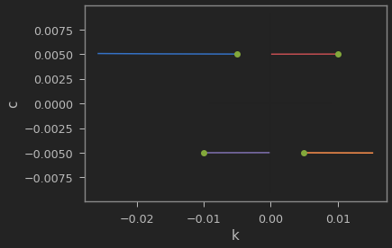

The green circle is the starting point, and the direction the line goes shows the character of how that point reacts around the steady state.

As it is easier to see in these graphs, the North-East and South-West curves verge to the steady state. While the North-West and South-East move away from the steady-state.

###### Saddle paths for above the stable point.

| 1 | test = plt.plot(v[:,0],v[:,1], 'b', v2[:,0],v2[:,1], 'r', |
| --- | --- |
| 2 | [0,0],[0.00498,.00505], 'black', [-.025, .010], [.00498,.00498], 'black',UpRtQ[0],UpRtQ[1],'go',UpLfQ[0],UpLfQ[1],'go'); |
| 3 | plt.xlabel('k',size=15) |
| 4 | plt.ylabel('c',size=15); |

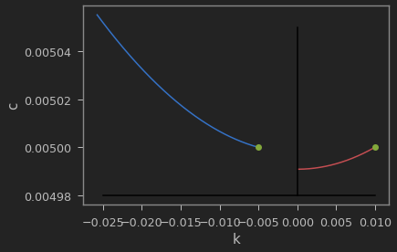

###### Saddle paths for below the stable point.

| 1 | plt.plot(v3[:,0],v3[:,1], 'm', v4[:,0],v4[:,1], 'y', |
| --- | --- |
| 2 | [0,0],[-0.00498,-0.005015], 'black', [-.010, .015], [-0.00498,-.00498], 'black', LwRtQ[0],LwRtQ[1],'go',LwLfQ[0],LwLfQ[1],'go'); |
| 3 | plt.xlabel('k',size=15) |
| 4 | plt.ylabel('c',size=15); |

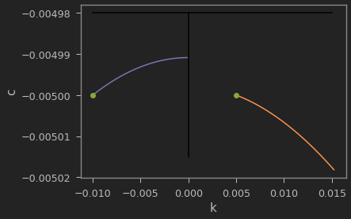